# 2018-11-15 qbic test

Theresa Swayne

11/15/2018

## Testing nuclear detection and DNA content analysis

The background-corrected integrated intensity (“total intensity”) of nuclei should be proportional to DNA content.

The DNA content in a mixed population of actively cycling cells should form a roughly bimodal distribution representing 1N and 2N populations, with some intermediate cells in S phase.

CellProfiler pipelines were used to perform background correction, identify nuclei using DAPI, and measure intensity of DAPI and other channels in a set of 100 images collected on 11-5-2018.

Reading the data from CellProfiler, we focus on the corrected integrated intensity from Channel 1, DAPI:

```r
qbic_C1DNANuclei <- read_csv("~/Desktop/output/qbic_C1DNANuclei.csv")
#dnaTotalInt <- qbic_C1DNANuclei$Intensity_IntegratedIntensity_Channel1DNA
dnaTotalInt <- qbic_C1DNANuclei$Intensity_IntegratedIntensity_Channel1DNACorr
```

Plotting a histogram of the DNA content over all 2765 nuclei detected:

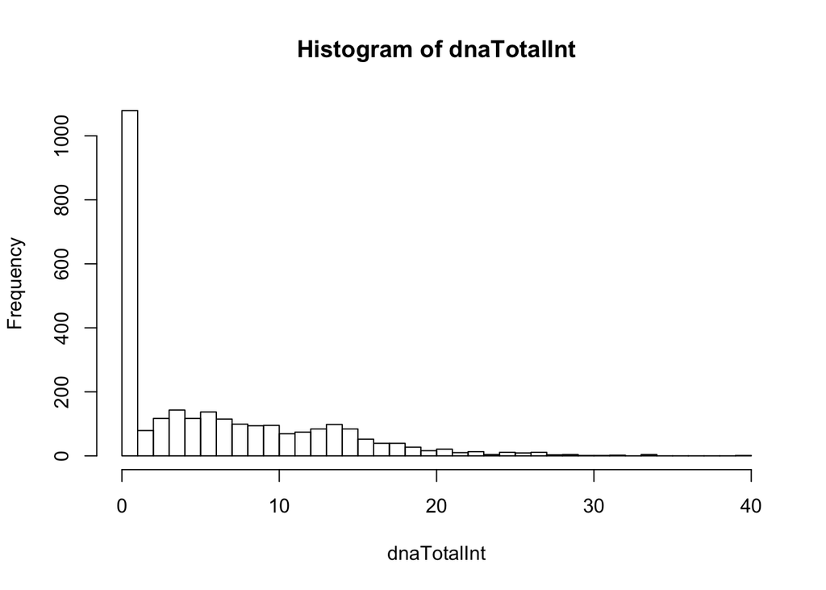

```r
# use echo=FALSE to prevent printing code
hist(dnaTotalInt, breaks = (0:40))
```

This shows that there is a roughly bimodal distribution with peaks ~ 6 and ~ 12, but with a long tail and an overwhelming number of cells with integrated intensity < 1.

```r
low_vals <- mean(dnaTotalInt < 1)
high_vals <- mean(dnaTotalInt > 20)
central_vals <- mean(dnaTotalInt > 1 & dnaTotalInt < 20)

cat(central_vals, "of the values are between 1 and 20; ",low_vals,"<1; and",high_vals,">20")
```

```
## 0.5734012 of the values are between 1 and 20;  0.3920785 <1; and 0.03452035 >20
```

Ultimately we would like to see an inverted horseshoe-type plot of EdU (showing S phase cells) vs. DNA content where the cells incorporating EdU are primarily those between the 2 peaks.

Generating the other dimension of the plot from the corrected mean intensity from Channel 2, EdU:

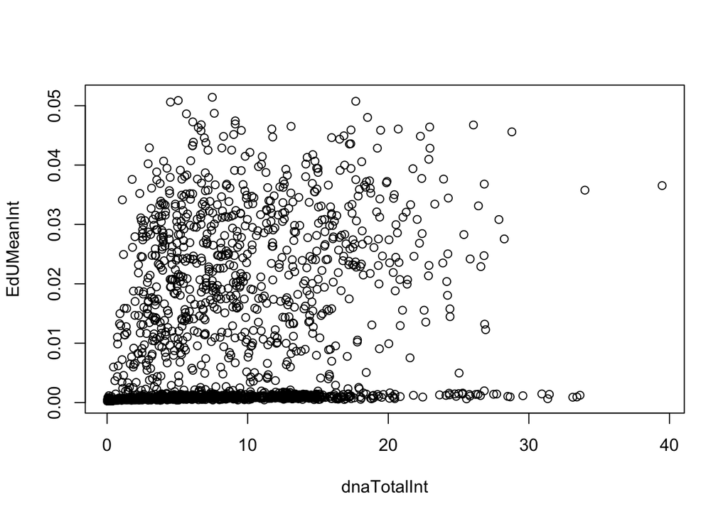

```r
#EdUMeanInt <- qbic_C1DNANuclei$Intensity_MeanIntensity_Channel2EdU
EdUMeanInt <- qbic_C1DNANuclei$Intensity_MeanIntensity_Channel2EdUCorr
plot(x = dnaTotalInt, y = EdUMeanInt) # basic scatter plot
```

Both the histogram and the scatter plot show that low intensities are predominating.

## Why so many low intensities?

### Are nuclei detected properly?

Select 10 images at random to check:

```r
rando <- sample((1:100), 10)
print(rando)
```

```
##  [1] 51 76 97 93 13 20 19 46 44 10
```

Comparing the original data to the mask generated by CellProfiler:

```r
qbic_check <- read_csv("~/Desktop/2018-11-05 Demis/2018-11-15 qbic test 1.csv")
kable(qbic_check[,1:5])
```

| Image | Cells detected by CP | False positives | False negatives | Cells detected by Analyze Particles |
| --- | --- | --- | --- | --- |
| 89 | 14 | NA | 0 | 9 |
| 51 | 20 | NA | 0 | 11 |
| 68 | 22 | NA | 0 | 16 |
| 85 | 14 | NA | 0 | 9 |
| 31 | 18 | NA | 0 | 13 |
| 65 | 3 | NA | 0 | 3 |
| 36 | 19 | NA | 0 | 9 |
| 45 | 47 | 47 | 0 | 39 |
| 13 | 21 | NA | 0 | 11 |
| 86 | 15 | NA | 0 | 8 |

From this, we can see that the saved mask does not reflect the counted particles.

The false negative rate is very low:

```r
false_neg <- sum(qbic_check$`False negatives`)
cat(false_neg, "false negatives out of", sum(qbic_check$`Cells detected by CP`), "cells")
```

```
## 0 false negatives out of 193 cells
```

But it’s not possible to see the false positive rate or understand the difference unless we get other documentation from CellProfiler.

Possibly, the extra particles are the source of the problem. If they were all false positives:

```r
false_pos <- sum(qbic_check$`Cells detected by CP`) - sum(qbic_check$`Cells detected by Analyze Particles`)
cat(false_pos, "POSSIBLE false positives out of", sum(qbic_check$`Cells detected by CP`), "cells, or",100*65/193,"%")
```

```
## 65 POSSIBLE false positives out of 193 cells, or 33.67876 %
```

The excess in cell detections is 33% of the total, and the low-value cells are 39% of the total. So the proportion is similar.

## Next steps

1. Instead of a mask, save more specific documentation of the particles CP detected
2. Find out if the additional particles CP detects are the source of the low intensities
3. Figure out how to filter the particles to limit to legitimate nuclei – suppress unwanted divisions.